# Incidence-based Design Simulation (6 variations)

Andrew Walther

2026-02-17

## 0. Preliminaries

- Design extension to project 1 “Spatial Cluster Randomized Trials - Sampling Design with Spillover Effects & Spatial Dependence” that incorporates heterogeneous incidence of the primary outcome.
- Consider multiple potential design strategies (Null Scenario, Intervention-High Incidence, Block stratification among high/low incidence) to address optimal strategy for study design with heterogeneous outcome incidence
- Understand which design achieves best estimation efficiency (minimal error) -> Sampling strategies when there is spillover, spatial dependence, and heterogeneous incidence of the outcome.
- How can we “best” design a study with known historical data on outcome incidences

## 1. Environment Setup

First, we load the necessary packages for spatial dependence, data manipulation, and visualization.

```r
# Install packages if not already installed
if (!require(spdep)) install.packages("spdep")
if (!require(dplyr)) install.packages("dplyr")
if (!require(ggplot2)) install.packages("ggplot2")
if (!require(viridis)) install.packages("viridis")

library(spdep)
library(dplyr)
library(ggplot2)
library(viridis)
```

## 2. Simulation Parameters & Toggles

Here we define the dimensions of our spatial grid, the values for spatial dependence ($\rho$) and spillover ($\gamma$), and the core parameters for the Spatial Durbin Model (SDM). We also include a toggle for Design 6 (Center Hotspot).

```r
# Toggle for Design 6 (Center Hotspot / Concentric Rings)
include_design_6 <- FALSE

# Base Parameters
n_designs_resamples <- 100
n_outcome_resamples <- 1000
grid_dim <- 10
N_clusters <- grid_dim^2
coords <- expand.grid(x = 1:grid_dim, y = 1:grid_dim)

# Spatial Parameters
rho_vals <- c(0.00, 0.01, 0.20, 0.50)
gamma_vals <- c(0.5, 0.6, 0.7, 0.8)
spill_types <- c("control_only", "both")
neighbor_types <- c("rook", "queen")

# SDM Parameters
true_tau <- 1.0   # Direct intervention effect
beta <- 1.0       # Effect of baseline incidence on outcome
sigma <- 1.0      # Variance of the error term

# Determine which designs to run
if(include_design_6) {
  design_ids <- 1:7
} else {
  design_ids <- c(1, 2, 3, 4, 5, 7)
}
```

## 3. Spatial Weight Matrices

We generate both Rook (edge-sharing) and Queen (edge- and vertex-sharing) contiguity matrices. We row-standardize them (`style = "W"`) as required by the Spatial Durbin Model.

```r
# Generate neighbor lists
nb_rook <- cell2nb(grid_dim, grid_dim, type = "rook")
nb_queen <- cell2nb(grid_dim, grid_dim, type = "queen")

# Generate Row-Standardized (style="W") Weight Matrices
W_rook <- nb2mat(nb_rook, style = "W", zero.policy = TRUE)
W_queen <- nb2mat(nb_queen, style = "W", zero.policy = TRUE)
```

## 4. Design Generator Function

This function dynamically generates the treatment assignment vectors for the specified sampling designs based on the simulation document specifications.

```r
get_designs <- function(design_id, n_resamples, N, incidence, nb_list) {
  mat <- matrix(0, nrow = N, ncol = n_resamples)

  if (design_id == 1) {
    # Design 1: Checkerboard (Block Stratification)
    cb1 <- (coords$x + coords$y) %% 2
    mat <- matrix(rep(cb1, n_resamples), ncol = n_resamples)

  } else if (design_id == 2) {
    # Design 2: High Incidence Focus
    med_val <- median(incidence)
    trt_assign <- ifelse(incidence > med_val, 1, 0)
    mat <- matrix(rep(trt_assign, n_resamples), ncol = n_resamples)

  } else if (design_id == 3) {
    # Design 3: Saturation Quadrants
    q_id <- ifelse(coords$x <= 5 & coords$y <= 5, 1,
            ifelse(coords$x > 5  & coords$y <= 5, 2,
            ifelse(coords$x <= 5 & coords$y > 5,  3, 4)))

    for (i in 1:n_resamples) {
      z <- numeric(N)
      current_sats <- sample(c(0.20, 0.40, 0.60, 0.80))
      for (q in 1:4) {
        idx <- which(q_id == q)
        n_trt <- round(length(idx) * current_sats[q])
        z[idx] <- sample(c(rep(1, n_trt), rep(0, length(idx) - n_trt)))
      }
      mat[, i] <- z
    }

  } else if (design_id == 4) {
    # Design 4: Intervention Isolation (Buffer)
    for (i in 1:n_resamples) {
      z <- numeric(N)
      available <- 1:N
      while(length(available) > 0) {
        target <- ifelse(length(available) == 1, available, sample(available, 1))
        z[target] <- 1
        neighbors <- nb_list[[target]]
        blocked <- c(target, neighbors)
        available <- setdiff(available, blocked)
      }
      mat[, i] <- z
    }

  } else if (design_id == 5) {
    # Design 5: 2x2 Blocking
    block_id <- paste((coords$x-1) %/% 2, (coords$y-1) %/% 2)
    unique_blocks <- unique(block_id)
    for (i in 1:n_resamples) {
      z <- numeric(N)
      for (b in unique_blocks) {
        idx <- which(block_id == b)
        z[idx] <- sample(c(1, 1, 0, 0))
      }
      mat[, i] <- z
    }

  } else if (design_id == 6) {
    # Design 6: Center Hotspot (Concentric Rings)
    dist_from_center <- pmax(abs(coords$x - 5.5), abs(coords$y - 5.5))
    rings <- as.numeric(as.factor(dist_from_center))
    for (i in 1:n_resamples) {
      z <- numeric(N)
      for (r in unique(rings)) {
        idx <- which(rings == r)
        n_half <- round(length(idx) / 2)
        z[idx] <- sample(c(rep(1, n_half), rep(0, length(idx) - n_half)))
      }
      mat[, i] <- z
    }

  } else if (design_id == 7) {
    # Design 7: Balanced Quartiles
    quartiles <- ntile(incidence, 4)
    for (i in 1:n_resamples) {
      z <- numeric(N)
      for (q in 1:4) {
        idx <- which(quartiles == q)
        n_half <- round(length(idx) / 2)
        z[idx] <- sample(c(rep(1, n_half), rep(0, length(idx) - n_half)))
      }
      mat[, i] <- z
    }
  }
  return(mat)
}
```

## 4.5 Sanity Check: Visualize Sample Designs with Uniform Incidence

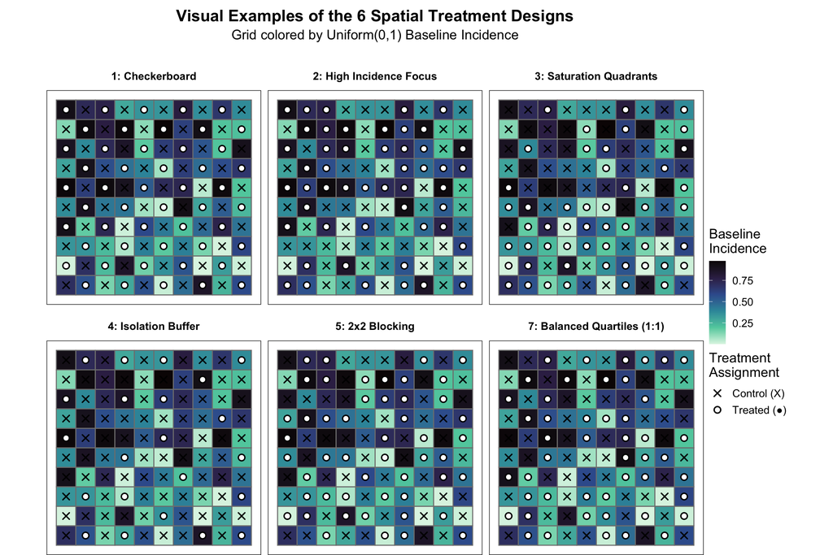

```r
set.seed(2026)

# 1. Generate uniformly distributed incidence from U(0,1)
dummy_incidence <- runif(N_clusters, 0, 1)

# Focus only on the 6 relevant designs
design_ids_to_plot <- c(1, 2, 3, 4, 5, 7)

design_names <- c(
  "1" = "1: Checkerboard",
  "2" = "2: High Incidence Focus",
  "3" = "3: Saturation Quadrants",
  "4" = "4: Isolation Buffer",
  "5" = "5: 2x2 Blocking",
  "7" = "7: Balanced Quartiles (1:1)"
)

# 2. Generate exactly 1 assignment vector for each design
sample_designs_list <- lapply(design_ids_to_plot, function(d) {

  z <- get_designs(design_id = d, n_resamples = 1, N = N_clusters,
                   incidence = dummy_incidence, nb_list = nb_queen)[, 1]

  data.frame(
    x = coords$x,
    y = coords$y,
    Incidence = dummy_incidence,
    Assignment = as.factor(z),
    Design = design_names[as.character(d)]
  )
})
sample_designs_df <- bind_rows(sample_designs_list)

# 3. Plot the 6 designs
plot_designs <- ggplot(sample_designs_df, aes(x = x, y = y)) +
  # Heatmap base layer mapped to Incidence
  geom_tile(aes(fill = Incidence), color = "grey50", linewidth = 0.5) +
  # Overlay treatment assignment as shapes
  geom_point(aes(shape = Assignment), fill = "white", color = "black", size = 2.5, stroke = 1) +
  # Continuous color scale for the Incidence heatmap
  scale_fill_viridis_c(option = "mako", direction = -1, name = "Baseline\nIncidence") +
  # Shape scale for Treatment Assignment
  scale_shape_manual(
    values = c("0" = 4, "1" = 21),
    labels = c("0" = "Control (X)", "1" = "Treated (\u25cf)"),
    name = "Treatment\nAssignment"
  ) +
  # Layout in a 3 columns by 2 rows grid
  facet_wrap(~ Design, ncol = 3) +
  theme_void(base_size = 14) +
  labs(
    title = "Visual Examples of the 6 Spatial Treatment Designs",
    subtitle = "Grid colored by Uniform(0,1) Baseline Incidence",
  ) +
  theme(
    legend.position = "right",
    plot.title = element_text(hjust = 0.5, face = "bold", margin = margin(b = 5, t = 10)),
    plot.subtitle = element_text(hjust = 0.5, margin = margin(b = 20)),
    strip.text = element_text(face = "bold", margin = margin(b = 10, t = 10)),
    panel.border = element_rect(color = "black", fill = NA, linewidth = 0.5)
  ) +
  coord_fixed()

# Print the visualization
print(plot_designs)
```

## 5. Main Simulation Execution

This chunk runs the fully vectorized Spatial Durbin Model. Note that `cache=TRUE` is set so you don’t have to re-run the simulation if you are just tweaking the visualizations below.

```r
results_list <- list()
list_index <- 1
total_scenarios <- length(neighbor_types) * length(rho_vals) * length(gamma_vals) * length(spill_types) * length(design_ids)

set.seed(2026)
start_time <- Sys.time()

cat("Starting SDM Simulation. Total scenarios:", total_scenarios, "\n")
```

```
## Starting SDM Simulation. Total scenarios: 384
```

```r
cat("--------------------------------------------------------------\n")
for (nb_type in neighbor_types) {

  # Set active matrix
  W <- if(nb_type == "rook") W_rook else W_queen
  active_nb <- if(nb_type == "rook") nb_rook else nb_queen
  I <- diag(N_clusters)

  for (rho in rho_vals) {

    # 1. SDM Spatial Multiplier: (I - rho*W)^-1
    inv_mat <- solve(I - rho * W)

    # 2. Baseline Matrix (X and Epsilon)
    X_matrix <- matrix(runif(N_clusters * n_outcome_resamples, 0, 1), ncol = n_outcome_resamples)
    Epsilon_matrix <- matrix(rnorm(N_clusters * n_outcome_resamples, 0, sigma), ncol = n_outcome_resamples)
    baseline_part <- inv_mat %*% (X_matrix * beta + Epsilon_matrix)

    for (gamma in gamma_vals) {
      for (spill_type in spill_types) {
        for (d_id in design_ids) {

          # Get treatment assignments (Uses X_matrix[, 1] for covariate-dependent designs)
          base_incidence <- X_matrix[, 1]
          Z_matrix <- get_designs(d_id, n_designs_resamples, N_clusters, base_incidence, active_nb)

          scenario_estimates <- numeric(n_designs_resamples * n_outcome_resamples)
          counter <- 1

          for (d_resample in 1:n_designs_resamples) {
            Z <- Z_matrix[, d_resample]

            # 3. Exogenous Spillover Term: WZ
            WZ <- as.vector(W %*% Z)
            spill_term <- if(spill_type == "control_only") gamma * WZ * (1 - Z) else gamma * WZ

            # 4. Final Y = Multiplier * (Treatment + Baseline)
            trt_effect_vector <- as.vector(inv_mat %*% (true_tau * Z + spill_term))
            Y_sim <- trt_effect_vector + baseline_part

            # 5. ESTIMATION STEP
            if (sum(Z) == 0 || sum(Z) == N_clusters) {
              ate_est <- rep(NA, n_outcome_resamples)
            } else {
              # Fast Naive Difference-in-Means
              mean_Y_trt <- colMeans(Y_sim[Z == 1, , drop = FALSE])
              mean_Y_ctrl <- colMeans(Y_sim[Z == 0, , drop = FALSE])
              ate_est <- mean_Y_trt - mean_Y_ctrl
            }

            idx_start <- counter
            idx_end <- counter + n_outcome_resamples - 1
            scenario_estimates[idx_start:idx_end] <- ate_est
            counter <- idx_end + 1
          }

          valid_estimates <- na.omit(scenario_estimates)

          results_list[[list_index]] <- data.frame(
            Neighbor_Type = nb_type,
            Design = paste("Design", d_id),
            Rho = rho,
            Gamma = gamma,
            Spillover_Type = spill_type,
            Mean_Estimate = mean(valid_estimates),
            Bias = mean(valid_estimates) - true_tau,
            SD = sd(valid_estimates),
            MSE = mean((valid_estimates - true_tau)^2)
          )
          list_index <- list_index + 1
        }
      }
    }
  }
}

granular_results <- bind_rows(results_list)
end_time <- Sys.time()
cat("--------------------------------------------------------------\n")
print(paste("Simulation finished in", round(difftime(end_time, start_time, units="mins"), 2), "minutes."))
```

```
## [1] "Simulation finished in 0.38 minutes."
```

## 6. Visualizations

Here we visualize the distribution of Mean Squared Error (MSE) to assess design performance across Rook and Queen contiguity assumptions.

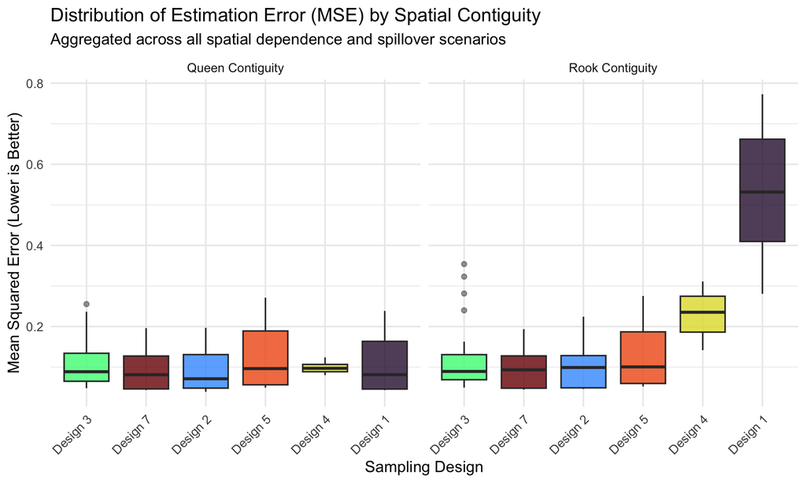

```r
# PLOT 1: Overall Design Robustness by Neighbor Type
plot_mse_overall <- ggplot(granular_results, aes(x = reorder(Design, MSE, FUN = median), y = MSE, fill = Design)) +
  geom_boxplot(alpha = 0.8, outlier.alpha = 0.5) +
  facet_wrap(~ Neighbor_Type, labeller = as_labeller(c("queen" = "Queen Contiguity", "rook" = "Rook Contiguity"))) +
  scale_fill_viridis_d(option = "turbo") +
  theme_minimal(base_size = 14) +
  labs(
    title = "Distribution of Estimation Error (MSE) by Spatial Contiguity",
    subtitle = "Aggregated across all spatial dependence and spillover scenarios",
    x = "Sampling Design",
    y = "Mean Squared Error (Lower is Better)"
  ) +
  theme(legend.position = "none", axis.text.x = element_text(angle = 45, hjust = 1))

print(plot_mse_overall)
```

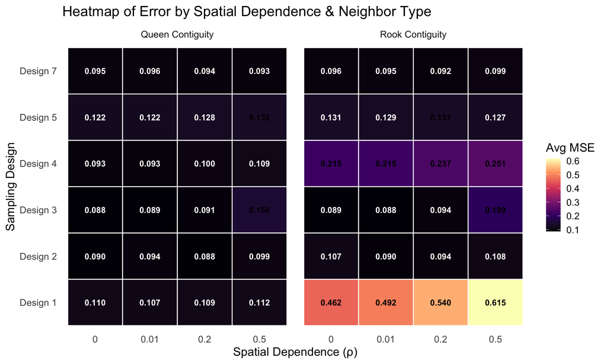

```r
# PLOT 2: Heatmap of MSE by Spatial Dependence (rho)
mse_rho_summary <- granular_results %>%
  group_by(Design, Rho, Neighbor_Type) %>%
  summarise(Avg_MSE = mean(MSE), .groups = "drop") %>%
  mutate(text_color = ifelse(Avg_MSE > quantile(Avg_MSE, 0.75), "black", "white"))

plot_mse_heatmap <- ggplot(mse_rho_summary, aes(x = as.factor(Rho), y = Design, fill = Avg_MSE)) +
  geom_tile(color = "white", linewidth = 0.5) +
  geom_text(aes(label = sprintf("%.3f", Avg_MSE), color = text_color), size = 3.5, fontface = "bold", show.legend = FALSE) +
  facet_wrap(~ Neighbor_Type, labeller = as_labeller(c("queen" = "Queen Contiguity", "rook" = "Rook Contiguity"))) +
  scale_fill_viridis_c(option = "magma") +
  scale_color_identity() +
  theme_minimal(base_size = 14) +
  labs(
    title = "Heatmap of Error by Spatial Dependence & Neighbor Type",
    x = "Spatial Dependence (\u03c1)",
    y = "Sampling Design",
    fill = "Avg MSE"
  ) +
  theme(panel.grid = element_blank())

print(plot_mse_heatmap)
```

```r
# ==============================================================================
# RESULTS TABLES: SUMMARY & COMPREHENSIVE
# ==============================================================================
if (!require(DT)) install.packages("DT")
library(DT)
library(dplyr)

# ------------------------------------------------------------------------------
# Table 1: High-Level Summary by Design
# ------------------------------------------------------------------------------
summary_by_design <- granular_results %>%
  group_by(Design) %>%
  summarise(
    Avg_Bias = mean(Bias),
    Avg_SD = mean(SD),
    Avg_MSE = mean(MSE)
  ) %>%
  arrange(Avg_MSE) # Sort best (lowest MSE) to worst

datatable(
  summary_by_design,
  caption = "Table 1: Overall Average Bias, SD, and MSE by Design",
  rownames = FALSE,
  options = list(dom = 't') # Simple table without search bars for the summary
) %>%
  formatRound(columns = c("Avg_Bias", "Avg_SD", "Avg_MSE"), digits = 4)
```

| Design | Avg_Bias | Avg_SD | Avg_MSE |
| --- | --- | --- | --- |
| Design 7 | -0.1260105803315677 | 0.2197878126642202 | 0.09496243567739984 |
| Design 2 | -0.1211675511795876 | 0.2151873118754863 | 0.09622104693382902 |
| Design 3 | -0.01086254678688069 | 0.2278150564682094 | 0.1097157014679649 |
| Design 5 | -0.253783380746493 | 0.2077309358341497 | 0.1278716887118311 |
| Design 4 | -0.3099251737705611 | 0.224746555138993 | 0.1640836974172829 |
| Design 1 | -0.4508060903091654 | 0.1936444857364918 | 0.3182580781986215 |

```r
# ------------------------------------------------------------------------------
# Table 2: Comprehensive Scenario-Specific Results
# ------------------------------------------------------------------------------
# The granular_results dataframe already contains the exact bias, SD, and MSE
# for every specific simulation parameter combination. We just format it nicely.

comprehensive_table <- granular_results %>%
  arrange(Design, Neighbor_Type, Spillover_Type, Rho, Gamma) %>%
  dplyr::select(Design, Neighbor_Type, Spillover_Type, Rho, Gamma, Bias, SD, MSE)

datatable(
  comprehensive_table,
  caption = "Table 2: Comprehensive Simulation Results by Scenario",
  rownames = FALSE,
  filter = "top", # Adds search/filter boxes for exploring specific scenarios
  options = list(pageLength = 12, autoWidth = TRUE, scrollX = TRUE)
) %>%
  formatRound(columns = c("Bias", "SD", "MSE"), digits = 4)
```

| Design | Neighbor_Type | Spillover_Type | Rho | Gamma | Bias | SD | MSE |
| --- | --- | --- | --- | --- | --- | --- | --- |
| Design 1 | queen | both | 0 | 0.5 | -0.04648668137931722 | 0.2061622858718539 | 0.04466347463268661 |
| Design 1 | queen | both | 0 | 0.6 | -0.05422001471265048 | 0.2061622858718532 | 0.0454422730824645 |
| Design 1 | queen | both | 0 | 0.7 | -0.06195334804598374 | 0.2061622858718535 | 0.04634068042113127 |
| Design 1 | queen | both | 0 | 0.8 | -0.06968668137931722 | 0.2061622858718532 | 0.04735869664868696 |
| Design 1 | queen | both | 0.01 | 0.5 | -0.03706844016603761 | 0.2073214290610683 | 0.04435581438251837 |
| Design 1 | queen | both | 0.01 | 0.6 | -0.04477966628941032 | 0.2073214290610683 | 0.04498696363916621 |
| Design 1 | queen | both | 0.01 | 0.7 | -0.05249089241278271 | 0.2073214290610683 | 0.0457370389124656 |
| Design 1 | queen | both | 0.01 | 0.8 | -0.06020211853615565 | 0.2073214290610682 | 0.04660604020241661 |
| Design 1 | queen | both | 0.2 | 0.5 | -0.04324419888422171 | 0.2102026666702046 | 0.04605477996079261 |
| Design 1 | queen | both | 0.2 | 0.6 | -0.05056768839106629 | 0.2102026666702045 | 0.04674181033287048 |

[output cut: 374 more lines]

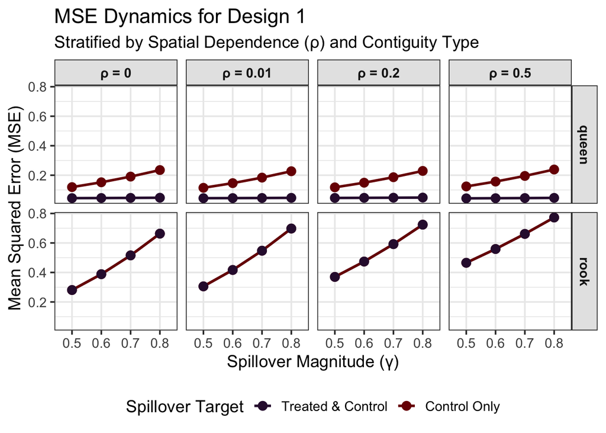

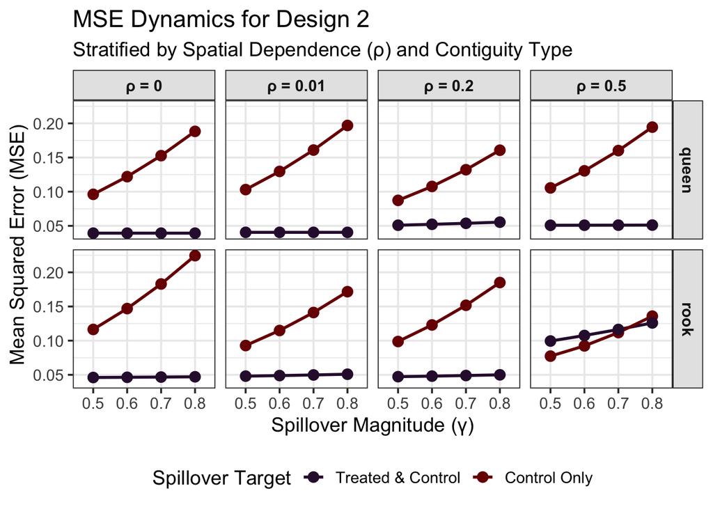

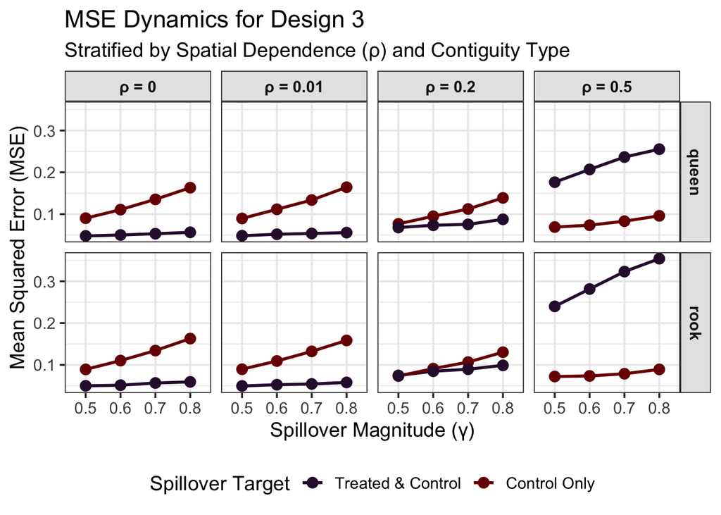

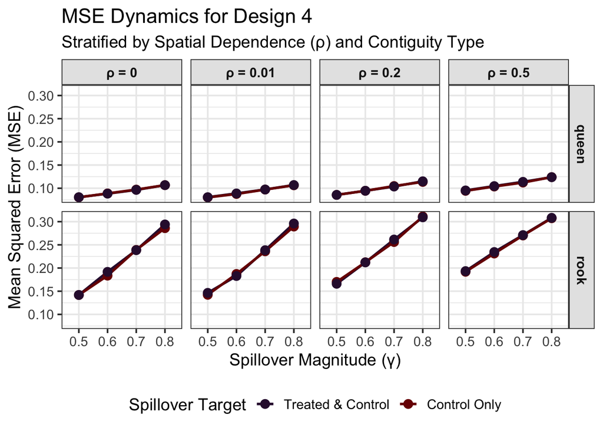

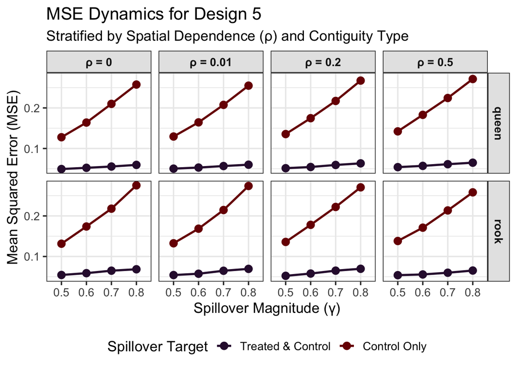

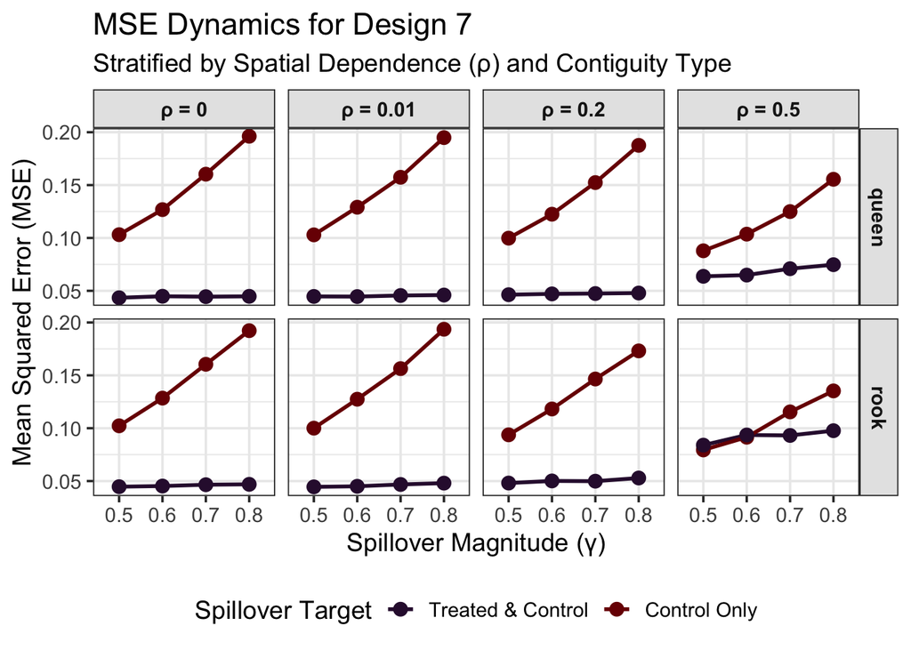

```r
# ==============================================================================
# FIGURE SET 1: DETAILED MSE BEHAVIOR PER DESIGN
# ==============================================================================
if (!require(ggplot2)) install.packages("ggplot2")
if (!require(viridis)) install.packages("viridis")

# Extract the unique design names
unique_designs <- sort(unique(granular_results$Design))

# Loop through each design and create a dedicated figure
for (current_design in unique_designs) {

  # Filter data for the specific design
  design_data <- granular_results %>% filter(Design == current_design)

  p_design <- ggplot(design_data, aes(x = as.factor(Gamma), y = MSE, color = Spillover_Type, group = Spillover_Type)) +
    geom_line(linewidth = 1) +
    geom_point(size = 3) +
    # Facet grid: Rho on the columns, Neighbor_Type on the rows
    facet_grid(Neighbor_Type ~ paste("\u03c1 =", Rho)) +
    scale_color_viridis_d(option = "turbo", labels = c("both" = "Treated & Control", "control_only" = "Control Only")) +
    theme_bw(base_size = 14) +
    labs(
      title = paste("MSE Dynamics for", current_design),
      subtitle = "Stratified by Spatial Dependence (\u03c1) and Contiguity Type",
      x = "Spillover Magnitude (\u03b3)",
      y = "Mean Squared Error (MSE)",
      color = "Spillover Target"
    ) +
    theme(
      legend.position = "bottom",
      strip.background = element_rect(fill = "grey90"),
      strip.text = element_text(face = "bold")
    )

  # Print the plot so it renders in the document/console
  print(p_design)
}
```

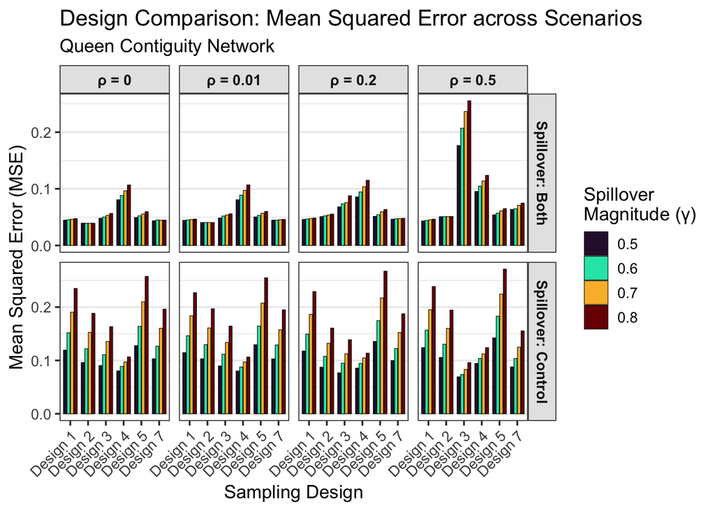

```r
# ==============================================================================
# FIGURE SET 2: MASTER DESIGN COMPARISON
# ==============================================================================

# Filter for Queen contiguity to prevent facet overcrowding
# (You can change this to "rook" to view the alternative spatial structure)
comparison_data <- granular_results %>% filter(Neighbor_Type == "queen")

plot_master_comparison <- ggplot(comparison_data, aes(x = Design, y = MSE, fill = as.factor(Gamma))) +
  # Grouped bar chart to show multiple Gamma values side-by-side for each design
  geom_col(position = position_dodge(width = 0.8), width = 0.7, color = "black", linewidth = 0.2) +
  # Facet grid: Rho on columns, Spillover_Type on rows (just like the attached image)
  facet_grid(
    Spillover_Type ~ paste("\u03c1 =", Rho),
    scales = "free_y", # Allows y-axis to adjust if high-rho errors explode
    labeller = labeller(Spillover_Type = c("both" = "Spillover: Both", "control_only" = "Spillover: Control"))
  ) +
  scale_fill_viridis_d(option = "turbo", name = "Spillover\nMagnitude (\u03b3)") +
  theme_bw(base_size = 13) +
  labs(
    title = "Design Comparison: Mean Squared Error across Scenarios",
    subtitle = "Queen Contiguity Network",
    x = "Sampling Design",
    y = "Mean Squared Error (MSE)"
  ) +
  theme(
    legend.position = "right",
    axis.text.x = element_text(angle = 45, hjust = 1, vjust = 1),
    strip.background = element_rect(fill = "grey90"),
    strip.text = element_text(face = "bold"),
    panel.grid.major.x = element_blank() # Cleans up background behind bars
  )

print(plot_master_comparison)
```